# Simulation v1 — Flexible Nonparametric Estimation of Random Coefficients

**Author:** Yihan Li · **Date:** July 14, 2026

Implements the **Simulation** to-do of the **Meeting Note** (2026-06-16), following the full method description in `summary` and `main1`.

## Contents

**Methodology:** Model · DGP · Estimation steps

**Code description:** Experiments · Parameters · Variable list

**Code (main part):**

1. Functions — Step 0 · Step 1 · Step 2 · Step 3
2. Simulation Experiments — Experiment A · Experiment B · Experiment C

**To be check**

## Methodology

### Model

Binary choice (Example 1 of `main1` with $J=2$) — with a **scalar random coefficient** $\beta_i \sim F_0$, $\beta_i \perp\!\!\!\perp X_i$:

$$\Pr\left(Y_i = 1 \mid X_i = x\right) \;=\; \int \frac{e^{x\beta}}{1+e^{x\beta}}\, dF_\beta \;=:\; \int g(x, \beta)\, dF_\beta .$$

The choice probability $g(x,\beta)$ is **logistic**; the observed $Y_i \in \{0,1\}$ is then **Bernoulli** with that probability. The goal is to estimate $F_0$ **nonparametrically**. FM's reformulation: write $\beta \overset{d}{=} q_0(U)$ for a base variable $U$ with known law ($U[0,1]$ or $N(0,1)$), estimate the function $q_0$ with a polynomial sieve, then recover $\hat F$ as the distribution of $\hat q(U)$.

### DGP

Panel with a **shared** coefficient per individual (FM's 1000 × 8 design; the Meeting Note's numbers "are mostly from FM"):

$$X_{it} \sim N(0, \sigma_X^2), \qquad \beta_i \sim F_0, \qquad Y_{it} \mid X_{it}, \beta_i \sim \text{Bernoulli}\big(g(X_{it}, \beta_i)\big), \qquad t = 1, \dots, T,$$

with $F_0 \in$ {Uniform $[-1,1]$, $N(0,1)$, mixture of two normals} and $R = 50$ Monte-Carlo replications. Setting $T = 1$ (`T_PANEL = 1`) gives the literal cross-section written in the Meeting Note — but for these three symmetric $F_0$'s that case is unidentified; see **To-be-check #1**.

### Estimation steps

**Step 1 (base draws).** Draw $\{u_m\}_{m=1}^{M}$ i.i.d. from the base law.

**Step 2 (simulated sieve MLE).** Polynomial sieve $q_a(u) = \sum_{k=0}^{K-1} a_k u^k$, and

$$\hat a \in \arg\max_a \hat L_{n,M}(a), \qquad \hat L_{n,M}(a) = \frac{1}{n} \sum_{i=1}^{n} \log \hat P_i(a), \qquad \hat P_i(a) = \frac{1}{M} \sum_{m=1}^{M} \prod_{t=1}^{T} g\big(X_{it}, q_a(u_m)\big)^{Y_{it}} \big(1 - g(X_{it}, q_a(u_m))\big)^{1-Y_{it}}.$$

At $T=1$ this is the full binary log-likelihood — the one-hot $\sum_j y_{i,j}\log P_j$ form of `main1`; the Meeting Note writes only the $Y_i$ term as shorthand (**To-be-check #2**).

**Step 3 (CDF reconstruction).** With fresh draws $\{v_s\}_{s=1}^{S}$ from the same base law,

$$\hat F(b) = \frac{1}{S} \sum_{s=1}^{S} \mathbb{1}\left\{ \textstyle\sum_{k=0}^{K-1} \hat a_k v_s^k \le b \right\}.$$

## Code description

### Experiments

|  | Description | Answers which Meeting-Note item |
| --- | --- | --- |
| **A** | Single-run estimation check, $n=1000$ | "Detailed estimation procedure: Step 1, 2, 3" |
| **B** | Pointwise $\hat F$ vs $F_0$: mean + 5–95% envelope over $R=50$ reps, both base laws, three $F_0$'s | "Comparison: $\hat F(b)$ v.s. $F_\beta(b)$ point-wise" |
| **C** | Mean $\max_b\lvert\hat F - F_0\rvert$ across $n \in \{250,\dots,4000\}$, log-log slope, for every $F_0$ | "Find whether $\max_x\lvert\hat F(x)-F(x)\rvert$ is convergent and possibly the convergence rate" |

Estimated running time: Experiments B and C run at the Meeting-Note $R = 50$ over the full grid. On a laptop, **Experiment B takes ≈ 15–20 min and Experiment C ≈ 4 hours** (2 bases × 2 $K$ × 3 $F_0$ × 5 sample sizes × 50 replications); both print progress lines as they go, so run them when you can leave the kernel busy. To shorten Experiment C, trim the top of `N_GRID` or lower `R_MC`. Experiments A and B use `K = 4`; Experiment C reports every $K$ in `K_LIST` independently.

### Parameters

| Symbol | Code name | Meaning | Default | Source |
| --- | --- | --- | --- | --- |
| $T$ | `T_PANEL` | choice occasions per individual (shared $\beta_i$) | 8 | FM's design; Meeting-Note literal is 1 — see To-be-check #1 |
| $n$ | `N_DEFAULT` | number of individuals (Exp A, B) | 1000 | Meeting Note |
| $R$ | `R_MC` | Monte-Carlo replications of the DGP (Exp B, C) | 50 | Meeting Note |
| $M$ | `M_SIM` | simulation draws $u_m$ inside the likelihood | 500 | Meeting Note |
| $S$ | `S_CDF` | fresh draws $v_s$ to rebuild $\hat F$ | 10 000 | tunable |
| $K$ | `K_LIST` | sieve order (coefficients $a_0,\dots,a_{K-1}$) | $\{3, 4\}$ | Meeting Note |
| $\sigma_X$ | `SIGMA_X` | sd of $X_{it}$ | 2.0 | unspecified; To-be-check #3 |
| — | `BASES` | law of base draws $u_m$ | Uniform $U[0,1]$ , $N(0,1)$ | Meeting Note |
| $F_0$ | `DISTS` | true $\beta$ distribution | Uniform $[-1,1]$, $N(0,1)$, two-normal mixture | Meeting Note |
| — | `N_GRID` | numbers of individuals for Exp C | 250 … 4000 | convergence study |
| — | `SEED` | master seed | 20260616 | reproducibility |

### Variable list

| Code variable | Math notation | Meaning / where it is used |
| --- | --- | --- |
| `X`, `Y` | $X_{it},\ Y_{it}$ | observed data, arrays of shape $(n, T)$; produced in Step 1 (DGP), consumed by the likelihood in Step 2 |
| `beta` | $\beta_i$ | latent coefficients drawn inside the DGP only (shared across $t$) — never seen by the estimator |
| `u` | $\{u_m\}_{m=1}^M$ | base draws inside $\hat L_{n,M}$ (Steps 1→2), fixed during optimization |
| `U_design` | $[u_m^k]_{M\times K}$ | monomial design matrix; row $m$ is $(1, u_m, \dots, u_m^{K-1})$, so $q_a(u_m) = (\texttt{U\_design}\,a)_m$ |
| `a`, `a_hat` | $a,\ \hat a$ | sieve coefficients; $\hat a$ maximizes $\hat L_{n,M}$ (Step 2) |
| `beta_m` | $q_a(u_m)$ | simulated coefficient values implied by $a$, inside the likelihood |
| `z` | $X_{it}\, q_a(u_m)$ | logit index for occasion $t$, an $(n, M)$ block inside the $t$-loop |
| `logL`, `L` | $\log L_{im},\ L_{im}$ | $\log$ / level of $\prod_t g^{Y}(1-g)^{1-Y}$ — individual $i$'s panel likelihood at draw $m$ |
| `S` | $\sum_t (Y_{it} - g_{imt}) X_{it}$ | logit score factor, used by the analytic gradient |
| `P` | $\hat P_i(a)$ | simulated individual likelihood $(1/M)\sum_m L_{im}$ |
| `v` | $\{v_s\}_{s=1}^S$ | fresh base draws for $\hat F$ (Step 3) |
| `b_grid` | $b$ | evaluation grid for the CDF comparison (distribution-specific) |
| `F_hat` | $\hat F(b)$ | estimated CDF on `b_grid` (Step 3) |
| `dist.cdf` | $F_0(b)$ | true CDF, for evaluation only |
| `sup_distance` | $\max_b \lvert\hat F - F_0\rvert$ | target quantity of Exp C |

## Code (main part)

The configuration cell sets all parameters; the function cells (Steps 0–3) define the estimator; the experiment cells produce the figures.

```python
# ============================================================
# Configuration (all tunable parameters live here)
# ============================================================
import time
import numpy as np
import matplotlib.pyplot as plt
from scipy.optimize import minimize
from scipy.special import expit, ndtr   # expit = logistic CDF; ndtr = standard normal CDF

# ---- Master seed (reproducibility) -------------------------
SEED = 20260616          # date of the Meeting Note

# ---- Panel dimension (see To-be-check #1) -------------------
T_PANEL = 8              # choices per individual, shared beta_i (FM's design: 1000 x 8).
                         # Set T_PANEL = 1 for the literal Meeting-Note cross-section.

# ---- Sample / simulation sizes (Meeting Note defaults) -----
N_DEFAULT = 1000         # n : number of individuals (Exp A, B)
R_MC      = 50           # R : Monte-Carlo replications of the DGP (Exp B and C)
M_SIM     = 500          # M : draws u_m inside the simulated likelihood
S_CDF     = 10000       # S : fresh draws v_s used to rebuild F-hat
K_LIST    = [3, 4]       # K : sieve order = number of coefficients (a_0 ... a_{K-1})

# ---- DGP ----------------------------------------------------
SIGMA_X = 2.0            # sd of X_it ~ N(0, SIGMA_X^2)   (see To-be-check #3)
BASES   = ["uniform", "normal"]            # law of the base draws u_m
DISTS   = ["uniform", "normal", "mixture"] # true beta distributions F_0

# ---- Experiment C (convergence of the sup-distance) --------
N_GRID = [250, 500, 1000, 2000, 4000]      # numbers of individuals n

# ---- Fixed, colorblind-safe color mapping (Okabe-Ito) -------
# Color follows the entity across ALL figures; K is encoded by linestyle.
COL_TRUE    = "#000000"  # true F_0 : always black
COL_UNIFORM = "#0072B2"  # estimates using the uniform base : always blue
COL_NORMAL  = "#D55E00"  # estimates using the normal  base : always vermillion
BASE_COLORS = {"uniform": COL_UNIFORM, "normal": COL_NORMAL}
K_STYLES    = {3: "--", 4: "-"}   # linestyle encodes sieve order K

plt.rcParams.update({"figure.dpi": 110, "axes.grid": True, "grid.alpha": 0.3,
                     "axes.spines.top": False, "axes.spines.right": False})
```

### 1. Functions

#### Step 0 — Model primitives

The known link function is the binary logit (Example 1 of `main1`, $J=2$):

$$g(x, \beta) = \frac{e^{x\beta}}{1 + e^{x\beta}} = \Pr\left(Y_{it} = 1 \mid X_{it} = x,\ \beta_i = \beta\right).$$

Each true distribution $F_0$ is packaged as a `TrueDist` object exposing `draw` (used only by the DGP), `cdf` (used only for evaluation), and its evaluation grid `b_grid`.

**Functions defined below:** `g_link(x, beta)` — logit link; `TrueDist` — container class; `DIST_REGISTRY` — the three $F_0$'s from the Meeting Note (uniform, normal, mixture of normals).

```python
# ============================================================
# Step 0 -- Model primitives
# ============================================================

def g_link(x, beta):
    """Logit link  g(x, beta) = e^{x beta} / (1 + e^{x beta}) = P(Y=1 | X=x, beta).

    Example 1 of main1 specialised to J = 2 (binary choice), scalar beta.
    `expit` is the numerically stable logistic CDF. Accepts arrays (broadcasting).
    """
    return expit(x * beta)


class TrueDist:
    """Container for a true distribution F_0 of the random coefficient beta.

    Attributes
    ----------
    name   : label used in tables / figures
    draw   : draw(rng, size) -> beta draws from F_0   (used ONLY inside the DGP)
    cdf    : cdf(b) -> F_0(b), the true CDF            (used ONLY for evaluation)
    b_grid : evaluation grid b for the pointwise / sup-norm comparison
    """
    def __init__(self, name, draw, cdf, b_grid):
        self.name, self.draw, self.cdf, self.b_grid = name, draw, cdf, b_grid


DIST_REGISTRY = {
    # Uniform[-1, 1]
    "uniform": TrueDist(
        name="Uniform[-1,1]",
        draw=lambda rng, size: rng.uniform(-1.0, 1.0, size),
        cdf=lambda b: np.clip((np.asarray(b) + 1.0) / 2.0, 0.0, 1.0),
        b_grid=np.linspace(-1.6, 1.6, 401),
    ),
    # Standard normal N(0,1)
    "normal": TrueDist(
        name="N(0,1)",
        draw=lambda rng, size: rng.standard_normal(size),
        cdf=lambda b: ndtr(np.asarray(b)),
        b_grid=np.linspace(-3.5, 3.5, 401),
    ),
    # Equal-weight mixture of N(-1, 0.5^2) and N(+1, 0.5^2)  (FM's two-normal mixture)
    "mixture": TrueDist(
        name="0.5 N(-1,0.5^2) + 0.5 N(1,0.5^2)",
        draw=lambda rng, size: np.where(rng.random(size) < 0.5, -1.0, 1.0)
                               + 0.5 * rng.standard_normal(size),
        cdf=lambda b: 0.5 * ndtr((np.asarray(b) + 1.0) / 0.5)
                      + 0.5 * ndtr((np.asarray(b) - 1.0) / 0.5),
        b_grid=np.linspace(-3.0, 3.0, 401),
    ),
}
```

#### Step 1 — Data-generating process

$$X_{it} \sim N(0, \sigma_X^2), \qquad \beta_i \sim F_0, \qquad Y_{it} \mid X_{it}, \beta_i \sim \text{Bernoulli}\big(g(X_{it}, \beta_i)\big), \qquad t = 1,\dots,T,$$

all i.i.d. across $i$, with $\beta_i \perp\!\!\!\perp X_{it}$ and $\beta_i$ **shared across the $T$ occasions** — the within-person persistence is what identifies the shape of $F_0$ (FM's design).

**Function defined below:** `simulate_data(n, dist, rng)` — returns one sample `(X, Y)` of shape $(n, T)$; the $\beta_i$ stay latent.

```python
# ============================================================
# Step 1 -- Data-generating process (panel with shared beta_i)
# ============================================================

def simulate_data(n, dist, rng):
    """DGP: one sample of n individuals x T_PANEL choice occasions.

    X_it   ~ N(0, SIGMA_X^2)  i.i.d. across (i, t)          (observed)
    beta_i ~ F_0              i.i.d. across i, SHARED across t (LATENT)
    Y_it | X_it, beta_i ~ Bernoulli( g(X_it, beta_i) ),  independent across t given beta_i

    The DGP samples beta_i directly, so it never integrates over F_0: the mixed-logit
    integral P(Y=1|x) = int g(x,b) dF_0(b) only appears at the ESTIMATION stage, where
    beta is unobserved and must be averaged out.  The shared beta_i across the T
    occasions is what carries information about F_0 (FM's 1000 x 8 design); with
    T_PANEL = 1 this collapses to the literal Meeting-Note cross-section (To-be-check #1).

    Returns (X, Y), both float arrays of shape (n, T_PANEL); beta stays latent.
    """
    X = SIGMA_X * rng.standard_normal((n, T_PANEL))
    beta = dist.draw(rng, n)[:, None]                    # (n, 1): shared across t
    Y = (rng.random((n, T_PANEL)) < g_link(X, beta)).astype(float)
    return X, Y
```

#### Step 2 — Simulated sieve MLE

Sieve space (univariate case, eq. (14) of `main1`):

$$q_a(u) = \sum_{k=0}^{K-1} a_k u^k =\phi_K(u)^\top a $$

with $a \in \mathbb{R}^K$ and $\phi_K(u)=(1,u,\dots,u^{K-1})^\top$.

The simulated panel objective is

$$\hat L_{n,M}(a) = \frac{1}{n} \sum_{i=1}^{n} \log \hat P_i(a), \qquad \hat P_i(a) = \frac{1}{M} \sum_{m=1}^{M} \underbrace{\prod_{t=1}^{T} g_{imt}^{Y_{it}} (1 - g_{imt})^{1-Y_{it}}}_{=:\ L_{im}}, \qquad g_{imt} = g\big(X_{it},\, q_a(u_m)\big),$$

maximized by BFGS with the **analytic gradient**. Using the logit score $\frac{\partial}{\partial \beta} \log\left[g^y (1-g)^{1-y}\right] = (y - g)\,x$ and the chain rule $\partial q_a(u_m) / \partial a_k = u_m^k$:

$$\frac{\partial \hat P_i}{\partial a_k} = \frac{1}{M} \sum_{m=1}^{M} L_{im}\, S_{im}\, u_m^k, \qquad S_{im} = \sum_{t=1}^{T} \big(Y_{it} - g_{imt}\big) X_{it}, \qquad \frac{\partial \hat L}{\partial a_k} = \frac{1}{n} \sum_{i=1}^{n} \frac{1}{\hat P_i} \frac{\partial \hat P_i}{\partial a_k}.$$

Numerical stability: $y \log g + (1-y)\log(1-g) = y z - \log(1 + e^{z})$ with $z = x\, q_a(u_m)$, computed as `y*z - logaddexp(0, z)` — this avoids overflow of $e^z$ when the index is large (which it can be after summing over the $T$ occasions).

**Functions defined below:** `draw_base` — draws $u_m$; `build_design` — monomial matrix $[u_m^k]$; `neg_loglik_and_grad` — $(-\hat L_{n,M}, -\nabla_a \hat L_{n,M})$; `canonical_start` — deterministic initial $a$; `fit_sieve_mle` — BFGS wrapper returning $\hat a$ for one $K$.

```python
# ============================================================
# Step 2 -- Simulated sieve MLE
# ============================================================

def draw_base(base_kind, size, rng):
    """Draw base random variables:  u ~ U[0,1] ('uniform') or u ~ N(0,1) ('normal')."""
    if base_kind == "uniform":
        return rng.random(size)
    if base_kind == "normal":
        return rng.standard_normal(size)
    raise ValueError(f"unknown base_kind: {base_kind}")


def build_design(u, K):
    """Monomial design matrix [u_m^k] of shape (len(u), K), columns k = 0,...,K-1.

    Row m is (1, u_m, u_m^2, ..., u_m^{K-1}), so the sieve polynomial is
    q_a(u_m) = (design @ a)_m = sum_k a_k u_m^k.
    """
    return np.vander(u, K, increasing=True)


def neg_loglik_and_grad(a, X, Y, U_design):
    """Negative simulated sieve log-likelihood -L_hat_{n,M}(a) and its analytic gradient.

    Panel likelihood (individual i's T choices share one beta):

      L_hat_{n,M}(a) = (1/n) sum_i log P_hat_i(a),
      P_hat_i(a)     = (1/M) sum_m  prod_t  g_imt^{Y_it} (1-g_imt)^{1-Y_it},
      g_imt          = g( X_it, q_a(u_m) ).

    Numerically stable log:  y log g + (1-y) log(1-g) = y z - log(1 + e^z),  z = x q_a(u),
    computed as  y*z - logaddexp(0, z).

    Analytic gradient (logit score d/d(beta) log[g^y (1-g)^{1-y}] = (y-g) x):
      dP_hat_i/da_k = (1/M) sum_m  L_im  S_im  u_m^k,
      S_im = sum_t (Y_it - g_imt) X_it,   L_im = prod_t g^y (1-g)^{1-y}.

    Returns (-L_hat, -grad) for scipy.optimize.minimize(jac=True).
    """
    n, T = X.shape
    M = U_design.shape[0]
    beta_m = U_design @ a                            # (M,)   q_a(u_m)
    logL = np.zeros((n, M))                          # log prod_t g^y (1-g)^{1-y}
    S = np.zeros((n, M))                             # sum_t (y - g) x   (score factor)
    for t in range(T):
        z = np.outer(X[:, t], beta_m)                # (n,M)  X_it * q_a(u_m)
        y_t = Y[:, t][:, None]
        logL += y_t * z - np.logaddexp(0.0, z)       # y log g + (1-y) log(1-g)
        S += (y_t - expit(z)) * X[:, t][:, None]
    L = np.exp(logL)                                 # (n,M)  individual-by-draw likelihood
    P = np.clip(L.mean(axis=1), 1e-300, None)        # (n,)   P_hat_i(a)
    ll = np.mean(np.log(P))
    grad = ((L * S / P[:, None]) @ U_design).mean(axis=0) / M
    return -ll, -grad


def canonical_start(base_kind, K):
    """Deterministic starting value for the sieve coefficients a.

    uniform base : q(u) = -2 + 4u   maps U[0,1] onto [-2, 2]
    normal  base : q(u) = u         i.e. start from beta ~ N(0,1)
    Higher-order coefficients start at 0.
    """
    a0 = np.zeros(K)
    if base_kind == "uniform":
        a0[0], a0[1] = -2.0, 4.0
    else:
        a0[1] = 1.0
    return a0


def fit_sieve_mle(X, Y, base_kind, K, rng):
    """Step 2: maximize L_hat_{n,M} over a in R^K by BFGS, for one sieve order K.

    Returns a_hat: the best coefficient vector.
    """
    u = draw_base(base_kind, M_SIM, rng)
    U_design = build_design(u, K)
    a0 = canonical_start(base_kind, K)
    res = minimize(neg_loglik_and_grad, a0, args=(X, Y, U_design),
                   jac=True, method="BFGS", options={"maxiter": 500})
    return res.x
```

#### Step 3 — Rebuild $\hat F$ and the sup-distance

With i.i.d. base draws $\{v_s\}_{s=1}^{S}$,

$$\hat F(b) = \frac{1}{S} \sum_{s=1}^{S} \mathbb{1}\big\{ q_{\hat a}(v_s) \le b \big\},$$

a right-continuous empirical CDF (i.e. the operator $H\{\hat q\}$ in equation (19) of `main1`) evaluated by simulation. The comparison metric for Experiment C is $\max_b |\hat F(b) - F_0(b)|$ over `b_grid`.

**Functions defined below:** `Fhat_eval(a_hat, base_kind, K, b_grid, rng)` — empirical CDF of $q_{\hat a}(v_s)$; `sup_distance(F_hat, F_true)` — sup-norm over the grid; `run_once(...)` — one full Steps 1–3 pass, reused by all three experiments.

```python
# ============================================================
# Step 3 -- Rebuild F-hat and the sup-distance
# ============================================================

def Fhat_eval(a_hat, base_kind, K, b_grid, rng):
    """Step 3: estimator of the CDF of beta, evaluated on b_grid.

    F_hat(b) = (1/S) sum_s 1{ q_a_hat(v_s) <= b },  {v_s} fresh i.i.d. base draws.

    Implementation: sort q(v_s) once, then F_hat(b) = #(q <= b)/S via
    searchsorted (right-continuous empirical CDF).
    """
    v = draw_base(base_kind, S_CDF, rng)
    q_v = np.sort(build_design(v, K) @ a_hat)
    return np.searchsorted(q_v, b_grid, side="right") / q_v.size


def sup_distance(F_hat, F_true):
    """max_b |F_hat(b) - F_0(b)| over the evaluation grid (approximates the sup-norm)."""
    return float(np.max(np.abs(F_hat - F_true)))


def run_once(n, dist, base_kind, K, rep_seed):
    """One full pass of Steps 1-3 on one simulated dataset.

    Returns (F_hat on dist.b_grid, sup-distance to the true CDF).
    Reused by Experiments A, B and C.
    """
    rng = np.random.default_rng(rep_seed)
    X, Y = simulate_data(n, dist, rng)
    a_hat = fit_sieve_mle(X, Y, base_kind, K, rng)
    F_hat = Fhat_eval(a_hat, base_kind, K, dist.b_grid, rng)
    return F_hat, sup_distance(F_hat, dist.cdf(dist.b_grid))
```

### 2. Simulation Experiments

#### Experiment A — single-run sanity check

One dataset ($n = 1000$, $F_0$ = mixture of two normals — the hardest shape in FM), estimated with both base laws and $K \in \{3, 4\}$. This is a simple test of Steps 1→2→3 before the Monte-Carlo experiments; the plotted $\hat F$ should already track $F_0$ closely.

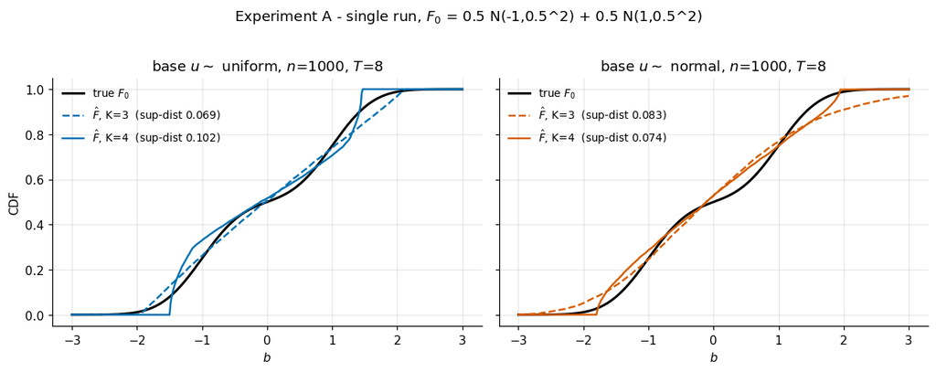

```
[Experiment A] elapsed: 8.0s
```

```python
# ============================================================
# Experiment A -- single-run sanity check  (n = 1000, F_0 = mixture)
# ============================================================

t0 = time.time()
dist_A = DIST_REGISTRY["mixture"] # could be changed to "uniform" or "normal" for other true distributions
fig, axes = plt.subplots(1, 2, figsize=(11, 4.2), sharey=True)
for ax, base in zip(axes, BASES):
    ax.plot(dist_A.b_grid, dist_A.cdf(dist_A.b_grid), color=COL_TRUE, lw=2,
            label="true $F_0$")
    for K in K_LIST:
        F_hat, sd = run_once(N_DEFAULT, dist_A, base, K,
                             rep_seed=np.random.SeedSequence([SEED, 900, K]))
        ax.plot(dist_A.b_grid, F_hat, K_STYLES[K], color=BASE_COLORS[base], lw=1.6,
                label=f"$\\hat F$, K={K}  (sup-dist {sd:.3f})")
    ax.set_title(f"base $u \\sim$ {base}, $n$={N_DEFAULT}, $T$={T_PANEL}")
    ax.set_xlabel("$b$")
    ax.legend(frameon=False, fontsize=9)
axes[0].set_ylabel("CDF")
fig.suptitle(f"Experiment A - single run, $F_0$ = {dist_A.name}", y=1.02)
plt.tight_layout()
plt.show()
print(f"[Experiment A] elapsed: {time.time()-t0:.1f}s")
```

#### Experiment B — pointwise Monte-Carlo comparison ($\hat F$ vs $F_0$)

The Meeting-Note comparison "$\hat F(b)$ v.s. $F_\beta(b)$ point-wise", in the style of FM Figure 1: for each true $F_0$ (rows) and each base law (columns), $R = 50$ replications of the DGP at $n = 1000$; plot the true CDF, the pointwise mean of $\hat F$, and the pointwise 5–95% envelope across replications.

Reading the output: a **tight envelope hugging the black curve** = the estimator recovers that shape well; envelopes widening at the tails or smoothing out the mixture's plateau reveal where the polynomial sieve struggles at this $K$.

**Function defined below:** `mc_pointwise(dist, base_kind, K, R, n, tag)` — stacks $R$ estimated CDF curves.

```
  done: F0=uniform  base=uniform   mean sup-dist = 0.0840   (178s elapsed)
  done: F0=uniform  base=normal    mean sup-dist = 0.0981   (319s elapsed)
  done: F0=normal   base=uniform   mean sup-dist = 0.0462   (543s elapsed)
  done: F0=normal   base=normal    mean sup-dist = 0.0457   (609s elapsed)
  done: F0=mixture  base=uniform   mean sup-dist = 0.1071   (866s elapsed)
  done: F0=mixture  base=normal    mean sup-dist = 0.0748   (1028s elapsed)
```

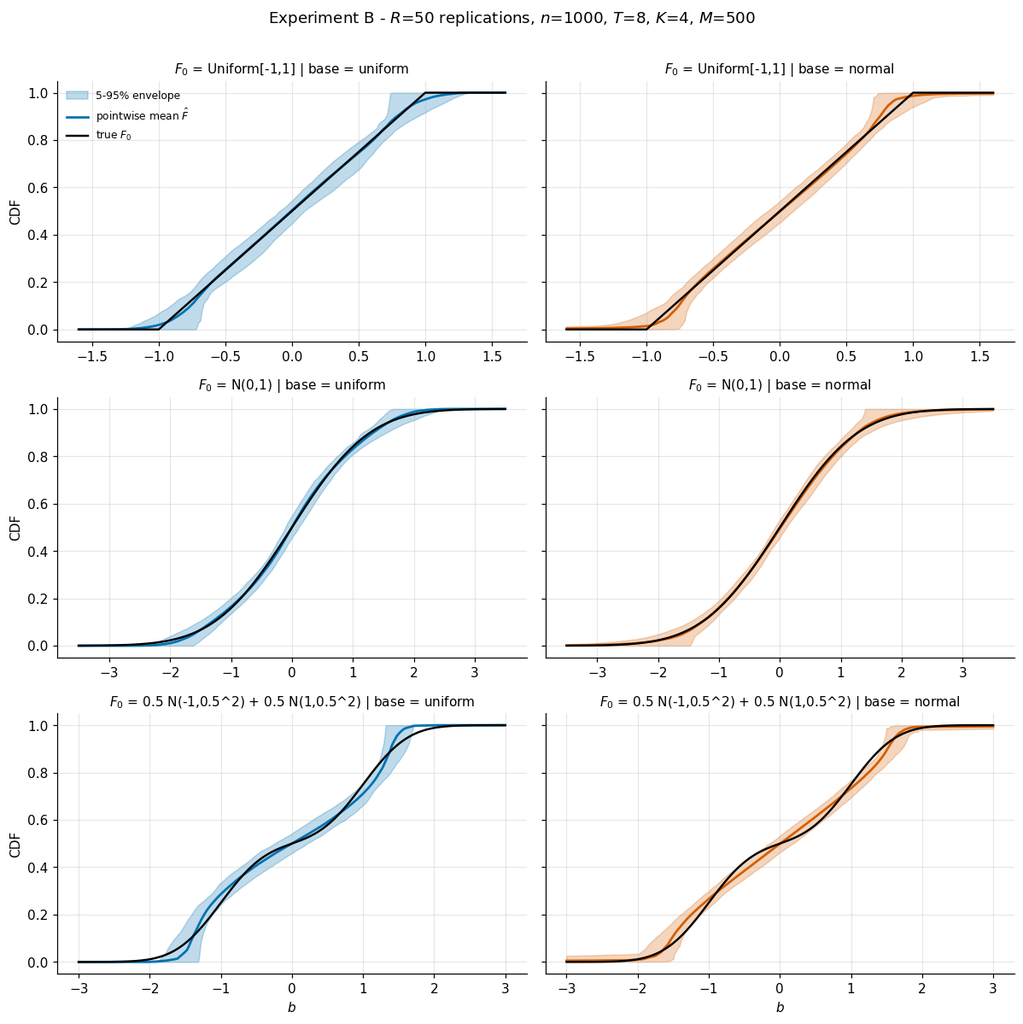

```
[Experiment B] total elapsed: 1028.3s
```

```python
# ============================================================
# Experiment B -- pointwise Monte-Carlo comparison (FM Fig. 1 style)
# R replications; plot true F_0, pointwise mean of F-hat, and the
# pointwise 5% / 95% envelope across replications.  K = 4 here.
# ============================================================

def mc_pointwise(dist, base_kind, K, R, n, tag):
    """R Monte-Carlo replications of Steps 1-3.

    Returns an (R, len(b_grid)) array whose row r is the F-hat curve of
    replication r.  `tag` separates the seed stream of each experimental cell.
    """
    children = np.random.SeedSequence([SEED, 100, tag]).spawn(R)
    F_hats = np.empty((R, dist.b_grid.size))
    for r in range(R):
        F_hats[r], _ = run_once(n, dist, base_kind, K, rep_seed=children[r])
    return F_hats


K_B = 4        # sieve order for this experiment (Meeting Note: K = 3 or 4)
t0 = time.time()
fig, axes = plt.subplots(len(DISTS), len(BASES),
                         figsize=(11, 3.6 * len(DISTS)), sharey=True)
for row, dist_key in enumerate(DISTS):
    dist = DIST_REGISTRY[dist_key]
    for col, base in enumerate(BASES):
        ax = axes[row, col]
        F_hats = mc_pointwise(dist, base, K_B, R_MC, N_DEFAULT, tag=row * 10 + col)
        lo, hi = np.percentile(F_hats, [5, 95], axis=0)
        c = BASE_COLORS[base]
        ax.fill_between(dist.b_grid, lo, hi, color=c, alpha=0.25,
                        label="5-95% envelope")
        ax.plot(dist.b_grid, F_hats.mean(axis=0), color=c, lw=1.8,
                label="pointwise mean $\\hat F$")
        ax.plot(dist.b_grid, dist.cdf(dist.b_grid), color=COL_TRUE, lw=1.6,
                label="true $F_0$")
        ax.set_title(f"$F_0$ = {dist.name} | base = {base}", fontsize=10)
        if row == len(DISTS) - 1:
            ax.set_xlabel("$b$")
        if col == 0:
            ax.set_ylabel("CDF")
        if row == 0 and col == 0:
            ax.legend(frameon=False, fontsize=8)
        mean_sd = np.mean([sup_distance(f, dist.cdf(dist.b_grid)) for f in F_hats])
        print(f"  done: F0={dist_key:8s} base={base:8s}  "
              f"mean sup-dist = {mean_sd:.4f}   ({time.time()-t0:.0f}s elapsed)")
fig.suptitle(f"Experiment B - $R$={R_MC} replications, $n$={N_DEFAULT}, "
             f"$T$={T_PANEL}, $K$={K_B}, $M$={M_SIM}", y=1.005)
plt.tight_layout()
plt.show()
print(f"[Experiment B] total elapsed: {time.time()-t0:.1f}s")
```

#### Experiment C — is $\max_b |\hat F - F_0|$ convergent, and how fast?

For **every** $F_0$, each base law, and $K \in \{3,4\}$, compute the mean sup-distance over $R = 50$ replications at each $n \in$ `N_GRID`, then fit a line in log-log space:

$$\log \mathbb{E}\Big[\max_b |\hat F - F_0|\Big] \approx c + \gamma \log n .$$

The fitted slope $\gamma$ is the empirical convergence-rate exponent ($\gamma = -0.5$ would be the parametric $n^{-1/2}$ rate).

**Function defined below:** `mc_supdist(dist, base_kind, K, n, R, tag)` — mean and sd of the sup-distance at one $(n, \text{base}, K)$.

```
  F0=uniform  base=uniform  K=3  slope=-0.33  (986s elapsed)
  F0=uniform  base=uniform  K=4  slope=-0.32  (2940s elapsed)
  F0=uniform  base=normal   K=3  slope=-0.10  (3454s elapsed)
  F0=uniform  base=normal   K=4  slope=-0.16  (4507s elapsed)
  F0=normal   base=uniform  K=3  slope=-0.11  (5477s elapsed)
  F0=normal   base=uniform  K=4  slope=-0.23  (7035s elapsed)
  F0=normal   base=normal   K=3  slope=-0.26  (7370s elapsed)
  F0=normal   base=normal   K=4  slope=-0.30  (7837s elapsed)
  F0=mixture  base=uniform  K=3  slope=-0.10  (8733s elapsed)
  F0=mixture  base=uniform  K=4  slope=-0.06  (10642s elapsed)
  F0=mixture  base=normal   K=3  slope=-0.07  (11276s elapsed)
  F0=mixture  base=normal   K=4  slope=-0.11  (12496s elapsed)
```

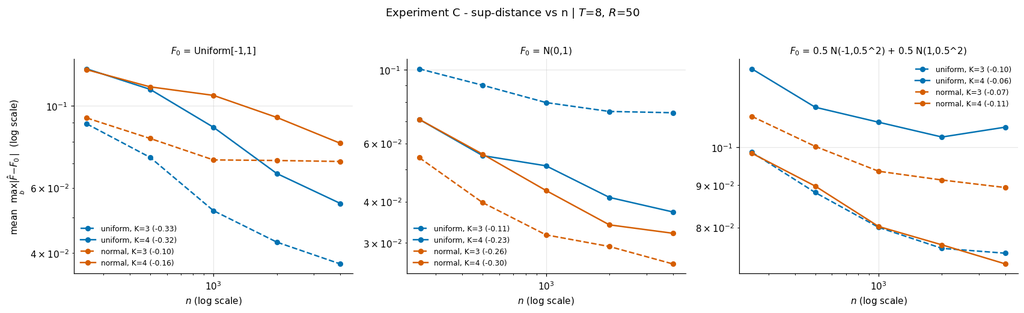

```
Fitted log-log slopes (sup-dist ~ n^slope; -0.5 would be the parametric rate):
F0         base        K    slope
uniform    uniform     3    -0.33
uniform    uniform     4    -0.32
uniform    normal      3    -0.10
uniform    normal      4    -0.16
normal     uniform     3    -0.11
normal     uniform     4    -0.23
normal     normal      3    -0.26
normal     normal      4    -0.30
mixture    uniform     3    -0.10
mixture    uniform     4    -0.06
mixture    normal      3    -0.07
mixture    normal      4    -0.11

[Experiment C] total elapsed: 12496.1s
```

```python
# ============================================================
# Experiment C -- convergence of  max_b |F-hat - F_0|  in n, for every F_0
# Meeting Note: "Find whether max_x |F-hat(x) - F(x)| is convergent
# and possibly the convergence rate."
# ============================================================

def mc_supdist(dist, base_kind, K, n, R, tag):
    """Mean and sd of the sup-distance over R replications at sample size n."""
    children = np.random.SeedSequence([SEED, 200, tag]).spawn(R)
    sds = np.empty(R)
    for r in range(R):
        _, sds[r] = run_once(n, dist, base_kind, K, rep_seed=children[r])
    return sds.mean(), sds.std(ddof=1)


t0 = time.time()
# results[(dist_key, base, K)] -> mean sup-distance for each n in N_GRID
results = {}
for d_i, dist_key in enumerate(DISTS):
    dist = DIST_REGISTRY[dist_key]
    for b_i, base in enumerate(BASES):
        for k_i, K in enumerate(K_LIST):
            means = []
            for n_i, n in enumerate(N_GRID):
                tag = d_i * 1000 + b_i * 100 + k_i * 10 + n_i
                m, _ = mc_supdist(dist, base, K, n, R_MC, tag)
                means.append(m)
            results[(dist_key, base, K)] = np.array(means)
            slope = np.polyfit(np.log(N_GRID), np.log(means), 1)[0]
            print(f"  F0={dist_key:8s} base={base:8s} K={K}  slope={slope:+.2f}  "
                  f"({time.time()-t0:.0f}s elapsed)")

# ---- one log-log panel per F_0 -----------------------------
fig, axes = plt.subplots(1, len(DISTS), figsize=(5.2 * len(DISTS), 4.6))
slope_rows = []
for ax, dist_key in zip(axes, DISTS):
    for base in BASES:
        for K in K_LIST:
            means = results[(dist_key, base, K)]
            slope = np.polyfit(np.log(N_GRID), np.log(means), 1)[0]
            slope_rows.append((dist_key, base, K, slope))
            ax.plot(N_GRID, means, K_STYLES[K], color=BASE_COLORS[base], marker="o",
                    ms=5, lw=1.6, label=f"{base}, K={K} ({slope:+.2f})")
    ax.set_xscale("log"); ax.set_yscale("log")
    ax.set_xlabel("$n$ (log scale)")
    ax.set_title(f"$F_0$ = {DIST_REGISTRY[dist_key].name}", fontsize=10)
    ax.legend(frameon=False, fontsize=8)
axes[0].set_ylabel(r"mean  $\max_b |\hat F - F_0|$  (log scale)")
fig.suptitle(f"Experiment C - sup-distance vs n | $T$={T_PANEL}, $R$={R_MC}", y=1.02)
plt.tight_layout()
plt.show()

print("\nFitted log-log slopes (sup-dist ~ n^slope; -0.5 would be the parametric rate):")
print(f"{'F0':10s} {'base':9s} {'K':>3s} {'slope':>8s}")
for dist_key, base, K, slope in slope_rows:
    print(f"{dist_key:10s} {base:9s} {K:3d} {slope:8.2f}")
print(f"\n[Experiment C] total elapsed: {time.time()-t0:.1f}s")
```

## To be check

**1. Cross-section (Meeting Note, literal) vs panel (FM) — the DGP as written is uninformative for these $F_0$'s.**

The Meeting-Note DGP line is a cross-section: one binary $Y_i$ per individual. For the three $F_0$'s the note names (uniform, normal, mixture of normals — **all symmetric about 0**) the cross-section carries *exactly zero* information about $F_0$: since $\frac{e^{z}}{1+e^{z}} + \frac{e^{-z}}{1+e^{-z}} = 1$, any $F_0$ symmetric about 0 gives $\Pr(Y_i=1 \mid X_i = x) = \int g(x\beta)\,dF_0 \equiv \tfrac12$ for every $x$ — every symmetric distribution is observationally equivalent. Diagnostics during development confirm it empirically: mean sup-distance flat at ≈ 0.25–0.35 from $n = 1000$ to $16{,}000$, with the fitted likelihood *exceeding* the likelihood at the true $q_0$ (wandering on a flat objective). FM's actual simulations use a **panel** — 1000 individuals × 8 choices with $\beta_i$ shared within individual — whose within-person correlation is what identifies $F_0$; the Meeting Note says its numbers "are mostly from FM".

*Current solution:* panel DGP with `T_PANEL = 8` (FM's design) as the default; the estimator then reaches sup-distances ≈ 0.03–0.10 at $n = 1000$.

*Alternatives:* (i) `T_PANEL = 1` **with an asymmetric $F_0$** (e.g. $N(1,1)$, or FM's shifted lognormal) — the cross-section is then informative, though still weakly; (ii) `T_PANEL = 1` with the symmetric $F_0$'s to demonstrate the non-identification.

**2. The likelihood in the Meeting Note has only the $Y_i$ term.** The note writes $\hat L_{n,M}(a) = \frac{1}{n}\sum_i Y_i \log(\cdot)$. Taken literally, the argmax pushes $\hat P_i \to 1$ for every $i$ (the $Y_i=0$ individuals never enter the objective, so nothing penalizes $\hat P_i \to 1$; degenerate).

*Current solution:* the full likelihood — for $T=1$, $Y_i \log \hat P_i + (1-Y_i)\log(1-\hat P_i)$, which **is** the one-hot $\sum_j y_{i,j} \log P_j$ objective of `main1` at $J = 2$; for the panel, $\log$ of the product over occasions. The note is shorthand.

**3. Distribution of $X$ is never specified.**

FM use $x \sim N(0,1)$ (standard normal) together with a **scale parameter $\sigma = 2$ inside the logit**, $P(1\mid\beta,x) = 1/(1+e^{\sigma(\beta-x)})$ — there $\sigma$ controls how steep the choice probability is in the index, and $\beta$ enters as a random location.

Our model $g(x,\beta) = \Lambda(x\beta)$ has $\beta$ as a random **slope** and no separate $\sigma$.

*Current solution:* fold a comparable steepness into the regressor, $X_{it} \sim N(0, 2^2)$; larger $|x|$ makes $g(x,\beta)$ vary sharply in $\beta$, which is what identifies the tails of $F_0$.

*Alternatives:* $X \sim N(0,1)$ (slower tail recovery), or add an explicit scale parameter to match FM's parameterization exactly.

**4. Bounded support assumption vs normal DGPs.** Assumption 1.1 of `main1` requires $\text{supp}(F_0) \subseteq [-M, M]$; the $N(0,1)$ and mixture DGPs violate this literally.

*Current solution:* keep them untruncated (FM does the same).

*Alternative:* truncate at $\pm 4$ sd — indistinguishable in practice.

**5. Method of optimization when computing the argmax.**

The estimator needs $\hat a = \arg\max_a \hat L_{n,M}(a)$, but the Meeting Note and `main1` do not prescribe how to solve it.

*Current solution:* unconstrained **BFGS** (`scipy.optimize.minimize(method="BFGS")`) with an **analytic gradient** (`jac=True`), `maxiter=500`, a single deterministic start per $K$ (`canonical_start`). Reason: the objective is smooth and low-dimensional ($K \le 4$), so a quasi-Newton method reaches superlinear convergence using only gradients — no Hessian, no numerical differentiation.